```python
!jupyter nbconvert --to html "/Labb1 (3).ipynb"
```

```
[NbConvertApp] Converting notebook /Labb1 (3).ipynb to html
[NbConvertApp] WARNING | Alternative text is missing on 9 image(s).
[NbConvertApp] Writing 1285098 bytes to /Labb1 (3).html
```

# Exercise 1

## Method

- We began by retrieving daily closing prices for the NASDAQ 100 index using the Yahoo Finance covering the period from 2021-01-01 to 2024-12-31.
- We then calculated daily log-returns from the closing prices and removed any missing values.

**To forecast volatility using Moving Average**

- We applied a 60-day rolling window computing the standard deviation of log-returns over the past 60 days. This gave us a simple historical estimate of volatility.

**Exponentially Weighted Moving Average (EWMA) method**

**Finally we plotted both MA an WENA daily volatility forecasts in the same figure. Additionally we plotted the log-returns to provide context for the volatility**

**Answer to discusion question 1**: The key difference between MA and EWMA volatility forecasts is how they weight past data. MA gives equal weight to all returns in the 60-day window while EWMA applies more weight to recent returns making it more responsive to sudden volatility shifts. This causes EWMA to react faster during volatile periods while MA lags behind.

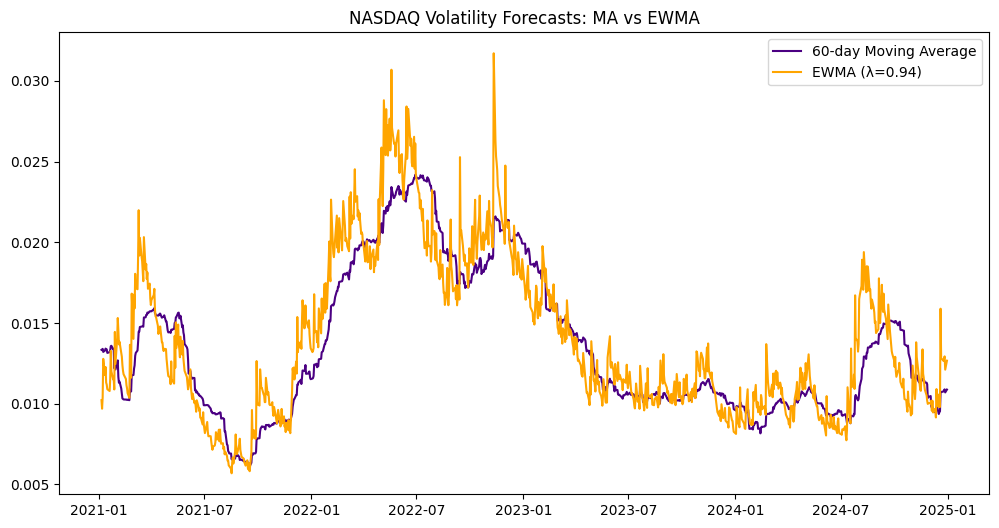

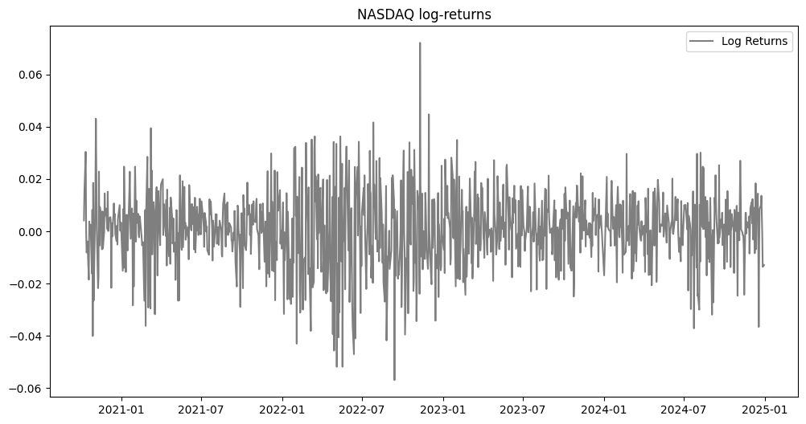

```python
import yfinance as yf
import pandas as pd
import numpy as np
import matplotlib.pyplot as plt
from scipy.optimize import minimize

# NASDAQ 2021-2024--------------------------------------------------------

nasdaq = yf.Ticker("^NDX")
nasdaq_data = nasdaq.history(start="2020-10-07", end="2024-12-31")
nasdaq_close = nasdaq_data["Close"]

log_returns = np.log(nasdaq_close/nasdaq_close.shift(1)).dropna()
#-------------------------------------------------------------------------


#MA60---------------------------------------------------------------------
def ma(log_returns, window = 60):
    n = len(log_returns)
    ma_vol, ind = np.zeros(n), np.arange(window, n)
    ma_vol[ind] = [np.std(log_returns[i-window: i]) for i in ind]  #std höjer upp avkastningen och tar roten ur summan
    ma_res = pd.Series(ma_vol, index = log_returns.index)
    return ma_res
#-------------------------------------------------------------------------

#EWMA---------------------------------------------------------------------

def ewma(log_returns, lambda_= 0.94, window = 60):
    n = len(log_returns)
    ewma_var = np.zeros(n)
    for t in range(window, n):
        ewma_var_K = ((1-lambda_)/(lambda_*(1-(lambda_**window))))* np.sum(lambda_**(np.arange(window-1, -1, -1))*(log_returns[t-window:t]**2))
        ewma_var[t] = (1 - lambda_) * (log_returns[t-1]**2) + lambda_ * ewma_var_K
    return pd.Series(np.sqrt(ewma_var), index=log_returns.index)


ma_res, ewma_res = ma(log_returns, window=60), ewma(log_returns, lambda_ = 0.94, window = 60)
ma_res = ma_res.replace(0, np.nan)
ewma_res = ewma_res.replace(0, np.nan)
#-------------------------------------------------------------------------


# Plot--------------------------------------------------------------------
plt.figure(figsize=(12,6))
plt.plot(ma_res["2021-01-01":], color="indigo", label="60-day Moving Average")
plt.plot(ewma_res["2021-01-01":], color="orange", label="EWMA (λ=0.94)")
plt.title("NASDAQ Volatility Forecasts: MA vs EWMA")
plt.legend()
plt.show()

plt.figure(figsize=(12,6))
plt.plot(log_returns, color="black", alpha=0.5, label="Log Returns")
plt.title("NASDAQ log-returns")
plt.legend()
plt.show()
```

# Exercise 2 and 3 a)

# Method exericese 2

- Downloaded Nasdaq index price data for two periods and calculated log-returns:
- Estimation period: 2011–2020
- Forecasting period: 2021–2024

Model specification:

- Chose a GARCH(1,1) model to capture volatility clustering in returns.

Parameter estimation:

- Set up a likelihood function for the GARCH(1,1) model.
- Used numerical optimization to estimate model parameters (ω, α, β).

Volatility forecasting:

- Applied the fitted GARCH(1,1) model to the 2021–2024 return data.
- Computed daily volatility forecasts (standard deviations from conditional variances).

Comparison with volatility methods:

- Computed volatility using moving average (MA) method.
- Computed volatility using exponentially weighted moving average (EWMA).

Visualization:

- Plotted GARCH forecasted volatility against MA and EWMA volatility estimates.

**Answer to discusion question 2**: The main reason for the difference between GARCH and EWMA volatility forecasts lies in how each model reacts to new information through the reaction and persistence terms.

In the EWMA model the reaction term is calculated as $( 1 - \lambda = 0.06 )$ while in the GARCH(1,1) model the reaction coefficient is $( \alpha = 0.14578 )$. This indicates that the GARCH model reacts more strongly to recent changes in log-returns than the EWMA model.

Regarding persistence the EWMA model uses $( \lambda = 0.94 )$ while the GARCH model includes a persistence term $( \beta = 0.81017 )$. Since persistence reflects how much past volatility influences current forecasts the higher value of $( \lambda )$ in EWMA shows that it places greater weight on historical volatility making it slower to adapt to changing market conditions compared to GARCH.

Exercise 3a)

- We extracted the optimized parameters from the estimation data and calculated the unconditional volatility and variance.

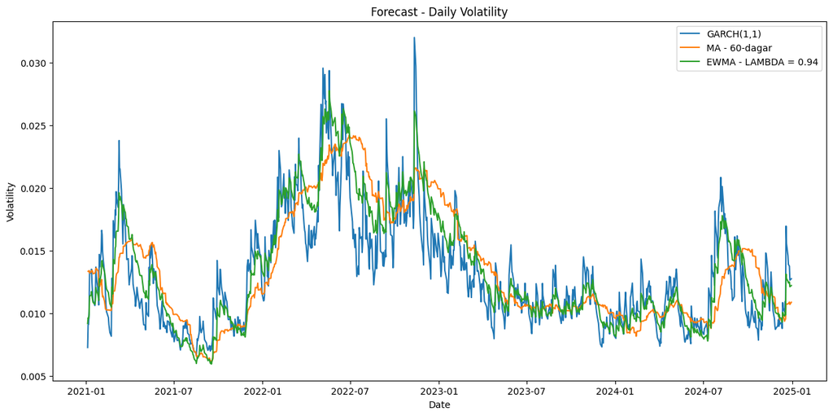

```
Omega:  6.070575383237363e-06

Alpha:  0.14577911504020713

Beta:  0.8101731364654772

Unconditional variance:  0.00013781806314165553

Unconditional volatility:  0.01173959382353817
```

```python
import yfinance as yf
import pandas as pd
import numpy as np
import matplotlib.pyplot as plt
from scipy.optimize import minimize

# NASDAQ 2011-2020 (Estimation period) ------------------------------------
nasdaq2 = yf.Ticker("^NDX")
nasdaq_data2 = nasdaq2.history(start="2011-01-01", end="2020-12-31")
nasdaq_close2 = nasdaq_data2["Close"]
log_returns2 = np.log(nasdaq_close2/nasdaq_close2.shift(1)).dropna()
#-------------------------------------------------------------------------

#GARCH function-----------------------------------------------------------

def garch(parameters, returns):
  omega, alpha, beta = parameters
  n = len(returns)
  var = np.zeros(n) #sigma**2 in garch(1,1)
  var[0] = returns.var()
  MLE = 0.0
  for t in range(1, n):
      var[t] = omega + alpha * returns[t-1]**2 + beta * var[t-1]
      MLE += 0.5*(np.log(var[t]) + (returns[t]**2 / var[t]))
  return MLE, var

def garch_mle(parameters, returns):
    mle, _ = garch(parameters, returns)
    return mle


initial_parameters = [0.00001, 0.1, 0.8]  # [omega, alpha, beta]
bounds = [(1e-8, 1), (0, 1), (0, 1)]
res = minimize(garch_mle, initial_parameters, args=(log_returns2,), bounds=bounds) # Optimize model parameters using estimation data 2011-2020
#-------------------------------------------------------------------------

# NASDAQ 2021-2024 (Forecast period) -------------------------------------

nasdaq = yf.Ticker("^NDX")
nasdaq_data = nasdaq.history(start="2020-10-07", end="2024-12-31")
nasdaq_close = nasdaq_data["Close"]

log_returns = np.log(nasdaq_close/nasdaq_close.shift(1)).dropna()
#-------------------------------------------------------------------------

#GARCH(1,1)
MLE, var = garch(res.x, log_returns.values)
daily_vol = pd.Series(np.sqrt(var), index=log_returns.index)

# MA and EWMA------------------------------------------------------------
def ma(log_returns, window = 60):
    n = len(log_returns)
    ma_vol, ind = np.zeros(n), np.arange(window, n)
    ma_vol[ind] = [np.std(log_returns[i-window: i]) for i in ind]
    ma_res = pd.Series(ma_vol, index = log_returns.index)
    return ma_res


def ewma(log_returns, lambda_= 0.94, window = 60):
    n = len(log_returns)
    ewma_var = np.zeros(n)
    ewma_var[0] = np.std(log_returns[:window])**2
    for t in range(1, n):
        ewma_var[t] = (1 - lambda_) * (log_returns[t-1]**2) + lambda_ * ewma_var[t-1]
    return pd.Series(np.sqrt(ewma_var), index=log_returns.index)


ma_res, ewma_res = ma(log_returns, window=60), ewma(log_returns, lambda_ = 0.94, window=60)
ma_res = ma_res.replace(0, np.nan)
ewma_res = ewma_res.replace(0, np.nan)
#-------------------------------------------------------------------------

# Plot-------------------------------------------------------------------

fig, ax = plt.subplots(figsize=(15, 7))
ax.plot(log_returns["2021-01-01":].index, daily_vol["2021-01-01":], label="GARCH(1,1)")
ax.plot(ma_res["2021-01-01":], label="MA - 60-dagar")
ax.plot(ewma_res["2021-01-01":], label="EWMA - LAMBDA = 0.94")
ax.set_title("Forecast - Daily Volatility")
ax.set_xlabel("Date")
ax.set_ylabel("Volatility")
ax.legend()
plt.show()


# 3a)
print("")
print("Omega: ", res.x[0])
print("")
print("Alpha: ", res.x[1])
print("")
print("Beta: ", res.x[2])
print("")
print("Unconditional variance: ",res.x[0]/(1-(res.x[1] + res.x[2])))
print("")
print("Unconditional volatility: ", np.sqrt(res.x[0]/(1-(res.x[1] + res.x[2]))))
print("")
```

### Exercise 3 b-e)

# Method Exercise 3

### Data preparation:

- Used Nasdaq index return data from estimation period 2011–2020
- Converted returns to numpy arrays for ACF calculations and residual analysis

### Model specification:

- Applied previously fitted GARCH(1,1) model from exercise 2
- Used standardized residuals for diagnostic testing

### Autocorrelation analysis (3b, 3c):

- Developed custom ACF function to compute autocorrelations up to lag 200
- Applied ACF calculation to raw returns and squared returns (3b)
- Calculated standardized residuals by dividing returns by GARCH volatilities
- Applied same ACF analysis to residuals and squared residuals (3c)
- We discarded first 100 observations to avoid initialization bias from the GARCH variance starting value (var[0] = returns.var()), to ensure that the residuals are based on stable converged volatility estimates rather than the arbitrary initial condition.

### Distribution diagnostics (3d, 3e):

- Created histogram of standardized residuals with 100 bins
- Overlaid theoretical normal PDF with matching sample statistics
- Generated QQ plots comparing residuals against normal and Student-t distributions
- Tested t-distributions with 7 and 8 degrees of freedom for tail fit assessment

### Visualization:

- Created 4-panel stem plots showing ACF patterns for returns, squared returns, residuals, and squared residuals
- Generated histogram with normal overlay for visual normality assessment
- Produced QQ plots for distributional comparison across normal and t-distributions

### Answer to discussion question 3d,e:

The histogram and QQ plots reveal that residuals are not normally distributed, showing excess kurtosis (fat tails). The Student-t distribution with 7-8 degrees of freedom provides better fit to the tail behavior, suggesting conditional returns follow a heavy-tailed distribution rather than normal.

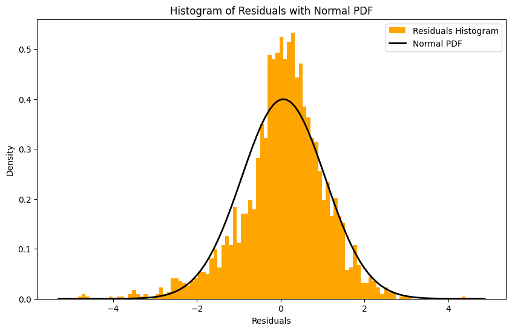

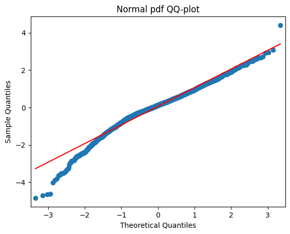

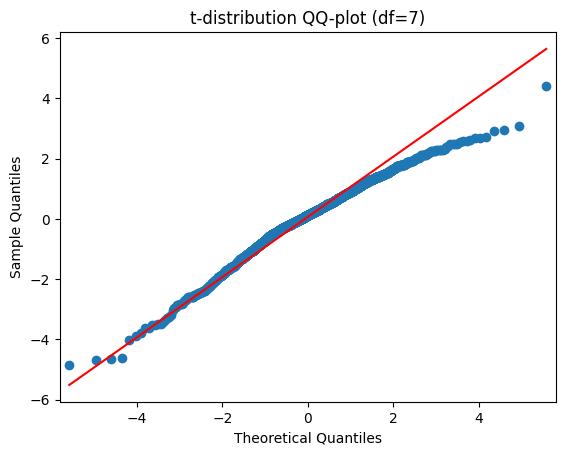

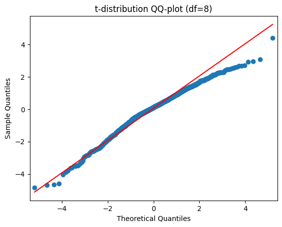

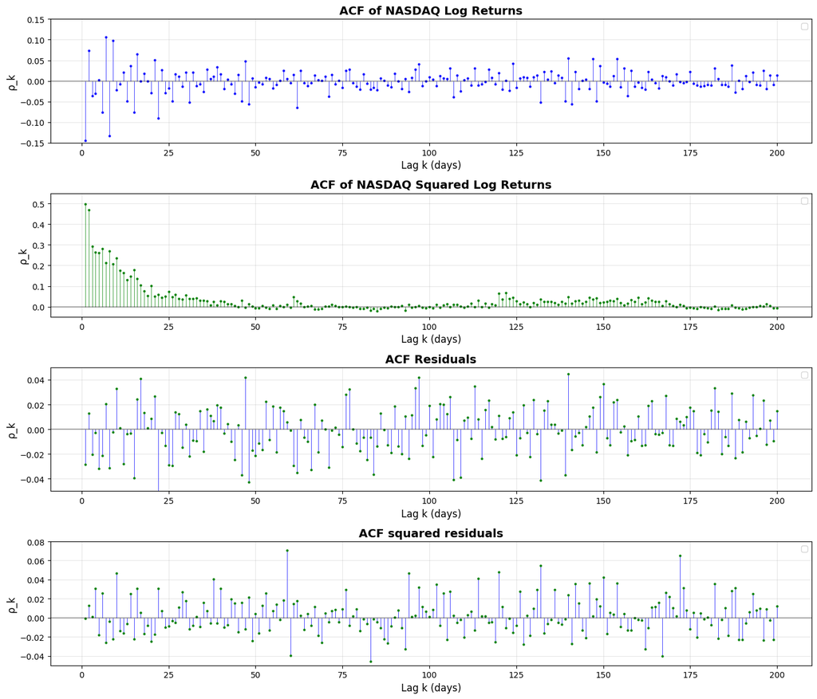

```python
import yfinance as yf
import pandas as pd
import numpy as np
import matplotlib.pyplot as plt
from scipy.optimize import minimize
from scipy import stats
import statsmodels.api as sm
from statsmodels.graphics.gofplots import qqplot




# NASDAQ 2011-2020 ----------------------------------------------------------------

nasdaq3 = yf.Ticker("^NDX")
nasdaq_data3 = nasdaq3.history(start="2011-01-01", end="2020-12-31")
nasdaq_close3 = nasdaq_data3["Close"]
log_returns3 = np.log(nasdaq_close3 / nasdaq_close3.shift(1)).dropna()
returns_array = log_returns3.values
squared_returns_array = returns_array**2
# --------------------------------------------------------------------------------


#ACF function---------------------------------------------------------------------

def calculate_acf(data, max_lag=200):

    T = len(data)
    y_bar = np.mean(data)
    y_demeaned = data - y_bar
    C_0 = np.mean(y_demeaned**2)
    acf_values = []
    for k in range(1, min(max_lag + 1, T)):
        C_k = np.mean(y_demeaned[:-k] * y_demeaned[k:]) * (T-k)/T
        rho_k = C_k / C_0
        acf_values.append(rho_k)

    return np.array(acf_values)
#b)
acf_returns = calculate_acf(returns_array, max_lag=200) #ACF returns
acf_squared = calculate_acf(squared_returns_array, max_lag=200) #ACF squared returns
#-----------------------------------------------------------------------------------

# GARCH(1,1)-----------------------------------------------------------------------

def garch(parameters, returns):
  omega, alpha, beta = parameters
  n = len(returns)
  var = np.zeros(n) #sigma**2 in garch(1,1)
  var[0] = returns.var()
  MLE = 0.0
  for t in range(1, n):
      var[t] = omega + alpha * returns[t-1]**2 + beta * var[t-1]
      MLE += 0.5*(np.log(var[t]) + (returns[t]**2 / var[t]))
  return MLE, var

def garch_mle(parameters, returns):
    mle, _ = garch(parameters, returns)
    return mle

initial_parameters = [0.00001, 0.1, 0.8]  # [omega, alpha, beta]
bounds = [(1e-8, 1), (0, 1), (0, 1)]
res = minimize(garch_mle, initial_parameters, args=(returns_array,), bounds=bounds)
MLE, var = garch(res.x, returns_array)
daily_vol = np.sqrt(var)
#-----------------------------------------------------------------------------------


#ACF residual----------------------------------------------------------------------
#c)
residuals1 = (returns_array[1:]/daily_vol[1:])
residuals1 = residuals1[100:]
residuals1_squared = (returns_array[1:]/daily_vol[1:])**2
residuals1_squared = residuals1_squared[100:]
acf_residuals = calculate_acf(residuals1, max_lag=200)
acf_residuals_squared = calculate_acf(residuals1_squared, max_lag=200)
#-----------------------------------------------------------------------------------


#d) Plot histogram of residuals with normal pdf
residuals_mean, residuals_std  = np.mean(residuals1), np.std(residuals1)
plt.figure(figsize=(10, 6))
plt.hist(residuals1, bins=100, density=True, color='orange', label='Residuals Histogram')
xmin, xmax = plt.xlim()
x = np.linspace(xmin, xmax, 100)
p = stats.norm.pdf(x, residuals_mean, residuals_std)
plt.plot(x, p, 'k', linewidth=2, label='Normal PDF')
plt.title('Histogram of Residuals with Normal PDF')
plt.xlabel('Residuals')
plt.ylabel('Density')
plt.legend()
plt.show()
#-----------------------------------------------------------------------------------

#e)


qqplot(residuals1, line='s');
plt.title('Normal pdf QQ-plot')
plt.show()

qqplot(residuals1, stats.t, distargs=(7,), line='s');
plt.title('t-distribution QQ-plot (df=7)')
plt.show()

qqplot(residuals1, stats.t, distargs=(8,), line='s');
plt.title('t-distribution QQ-plot (df=8)')
plt.show()


# PLOT------------------------------------------------------------------------------
fig, (ax1, ax2, ax3, ax4) = plt.subplots(4, 1, figsize=(14, 12))
lags = np.arange(1, 201)

# ACF of Returns
markerline, stemlines, baseline = ax1.stem(lags, acf_returns, basefmt=' ',
                                           linefmt='blue', markerfmt='bo')
markerline.set_markersize(2)
stemlines.set_linewidth(0.5)
ax1.axhline(y=0, color='black', linestyle='-', alpha=0.3)
ax1.set_title('ACF of NASDAQ Log Returns', fontsize=14, fontweight='bold')
ax1.set_xlabel('Lag k (days)', fontsize=12)
ax1.set_ylabel('ρ_k', fontsize=12)
ax1.set_ylim(-0.15, 0.15)
ax1.legend(loc='upper right')
ax1.grid(True, alpha=0.3)

# ACF of Squared Returns
markerline2, stemlines2, baseline2 = ax2.stem(lags, acf_squared, basefmt=' ',
                                              linefmt='green', markerfmt='go')
markerline2.set_markersize(2)
stemlines2.set_linewidth(0.5)
ax2.axhline(y=0, color='black', linestyle='-', alpha=0.3)
ax2.set_title('ACF of NASDAQ Squared Log Returns', fontsize=14, fontweight='bold')
ax2.set_xlabel('Lag k (days)', fontsize=12)
ax2.set_ylabel('ρ_k', fontsize=12)
ax2.set_ylim(-0.05, 0.55)
ax2.legend(loc='upper right')
ax2.grid(True, alpha=0.3)

# ACF of Residuals
markerline2, stemlines2, baseline2 = ax3.stem(lags, acf_residuals, basefmt=' ',
                                              linefmt='blue', markerfmt='go')
markerline2.set_markersize(2)
stemlines2.set_linewidth(0.5)
ax3.axhline(y=0, color='black', linestyle='-', alpha=0.3)
ax3.set_title('ACF Residuals', fontsize=14, fontweight='bold')
ax3.set_xlabel('Lag k (days)', fontsize=12)
ax3.set_ylabel('ρ_k', fontsize=12)
ax3.set_ylim(-0.05, 0.05)
ax3.legend(loc='upper right')
ax3.grid(True, alpha=0.3)


# ACF of squared residuals
markerline2, stemlines2, baseline2 = ax4.stem(lags, acf_residuals_squared, basefmt=' ',
                                              linefmt='blue', markerfmt='go')
markerline2.set_markersize(2)
stemlines2.set_linewidth(0.5)
ax4.axhline(y=0, color='black', linestyle='-', alpha=0.3)
ax4.set_title('ACF squared residuals', fontsize=14, fontweight='bold')
ax4.set_xlabel('Lag k (days)', fontsize=12)
ax4.set_ylabel('ρ_k', fontsize=12)
ax4.set_ylim(-0.05, 0.08)
ax4.legend(loc='upper right')
ax4.grid(True, alpha=0.3)


plt.tight_layout()
plt.show()
```

### Exericise 4 & 5

# Method 4

**Answer to discusion question 4**: Historical simulation is simple and does not assume a specific distribution of returns. It directly uses past data to generate risk estimates. However it can be slow to adapt to changing market conditions and may underestimate extreme events if they are not present in the historical window. Window size choice (500 vs. 1000 days) affects responsiveness. Shorter windows react faster while longer windows provide smoother but slower adjustments.

# Method 5

- Used 2011–2020 Nasdaq returns to fit a GARCH(1,1) model.
- Estimated model parameters with maximum likelihood.
- Assumed normally distributed conditional returns.
- Computed 98% VaR directly from conditional volatility forecasts.
- Standardized returns by GARCH volatility (residuals).
- Estimated percentiles of residuals from historical data.
- Re-scaled these residuals by conditional volatility to obtain filtered historical simulation VaR.
- Compared realized returns with both GARCH and FHS VaR forecasts.
- Counted violations and calculated violation ratios.
- Plotted returns, historical simulation VaR (500 & 1000) and GARCH & FHS VaR forecasts together.

**Answer to discusion question 5**: GARCH captures volatility clustering which helps during volatile periods but it assumes normal distributions which we saw isn't true (fat tails in exercise 3). This means GARCH-normal VaR underestimates extreme risks. FHS fixes this by combining GARCH volatility with the actual historical distribution instead of assuming normality so you get both volatility dynamics and realistic tails. The downside is it needs more data and computation time but our results show FHS performed better than plain GARCH so it's probably worth it.

```
500-day window:
Observed violations:   18
Violation ratio:       0.8964143426294819

1000-day window:
Observed violations:    14
Violation ratio:       0.697211155378486
```

```
FHS:
Observed violations:   19
Violation ratio:       0.946215139442231

GARCH:
Observed violations:    36
Violation ratio:       1.7928286852589639
```

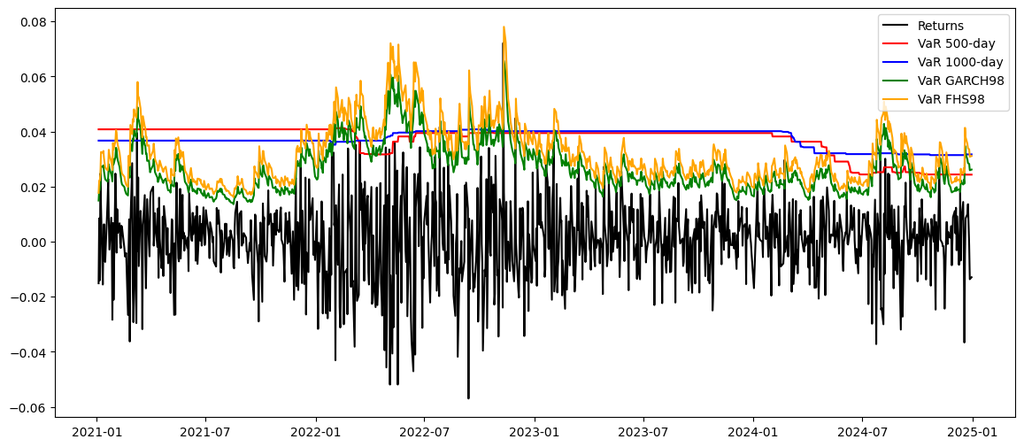

```python
import yfinance as yf
import pandas as pd
import numpy as np
import matplotlib.pyplot as plt
from scipy.optimize import minimize
from scipy import stats
from scipy.stats import norm
import statsmodels.api as sm

#Nasdaq 2021-2024--------------------------------------------------

nasdaq = yf.Ticker("^NDX")
nasdaq_data = nasdaq.history(start="2017-01-01", end="2024-12-31")
nasdaq_close = nasdaq_data["Close"]
log_returns = np.log(nasdaq_close/nasdaq_close.shift(1)).dropna()

#------------------------------------------------------------------

# 4 a) backtestning to compare daily VaR98-------------------------

def rolling_var(returns, window, alpha=0.98):
    var_list = []
    for i in range(window, len(returns)):
        window_returns = returns[i-window:i]
        var_ = -np.percentile(window_returns, 100*(1-alpha))
        var_list.append(var_)
    return pd.Series(var_list, index=returns.index[window:])

# Step 3: Calculate rolling VaR
var_500 = rolling_var(log_returns, 500, alpha=0.98)
var_1000 = rolling_var(log_returns, 1000, alpha=0.98)

var_500_2021 = var_500[var_500.index >= "2021-01-01"]
var_1000_2021 = var_1000[var_1000.index >= "2021-01-01"]

returns_2021 = log_returns[log_returns.index >= "2021-01-01"]

#------------------------------------------------------------------


# 4 b)-------------------------------------------------------------


def violation(returns, var_series):
    aligned_returns = returns.reindex(var_series.index).dropna()
    aligned_var = var_series.reindex(aligned_returns.index)
    violations = (aligned_returns < -aligned_var).sum()
    N = len(aligned_returns)
    expected = 0.02 * N
    ratio = violations / expected

    return violations, ratio

# 500-day window
violations_500, ratio_500 = violation(returns_2021, var_500_2021)

# 1000-day window
violations_1000, ratio_1000 = violation(returns_2021, var_1000_2021)

print("")
print("500-day window:")
print("Observed violations:  ", violations_500)
print("Violation ratio:      ", ratio_500)
print("")
print("1000-day window:")
print("Observed violations:   ", violations_1000)
print("Violation ratio:      ", ratio_1000)
print("")

# 5 a)------------------------------------------------------------
nasdaq_data_train = nasdaq.history(start="2011-01-01", end="2020-12-31")
nasdaq_close_train = nasdaq_data_train["Close"]
log_returns_train = np.log(nasdaq_close_train/nasdaq_close_train.shift(1)).dropna()


def garch(parameters, returns):
  omega, alpha, beta = parameters
  n = len(returns)
  var = np.zeros(n) #sigma**2 in garch(1,1)
  var[0] = returns.var()
  MLE = 0.0
  for t in range(1, n):
      var[t] = omega + alpha * returns[t-1]**2 + beta * var[t-1]
      MLE += 0.5*(np.log(var[t]) + (returns[t]**2 / var[t]))
  return MLE, var

def garch_mle(parameters, returns):
    mle, _ = garch(parameters, returns)
    return mle

initial_parameters = [0.00001, 0.1, 0.8]  # [omega, alpha, beta]
bounds = [(1e-8, 1), (0, 1), (0, 1)]
res = minimize(garch_mle, initial_parameters, args=(log_returns_train,), bounds=bounds)
MLE, var = garch(res.x, log_returns)
daily_vol = pd.Series(np.sqrt(var), index=log_returns.index)

var_garch = pd.Series(norm.ppf(0.98)*daily_vol, index=daily_vol.index)


#FHS-----------------------------------------------------------------------

def HS(garch_vol, returns):
  n = len(returns)
  HS_list = []
  for i in range(n):
    R = returns.iloc[i]/garch_vol.iloc[i]
    HS_list.append(R)
  return pd.Series(HS_list, index=returns.index)

HS_garch_residuals = HS(daily_vol, log_returns)

FHS_percentile = np.percentile(HS_garch_residuals, 2) # 2nd percentile for 98% VaR
var_FHS = pd.Series(-FHS_percentile * daily_vol, index=daily_vol.index)

# 5 b)--------------------------------------------------------------

var_garch = var_garch[var_garch.index >= "2021-01-01"]
var_FHS = var_FHS[var_FHS.index >= "2021-01-01"]
violation_HS, ratio_HS = violation(log_returns, var_FHS)
violation_GARCH, ratio_GARCH = violation(log_returns, var_garch)

print("")
print("FHS: ")
print("Observed violations:  ", violation_HS)
print("Violation ratio:      ", ratio_HS)
print("")
print("GARCH: ")
print("Observed violations:   ", violation_GARCH)
print("Violation ratio:      ", ratio_GARCH)
print("")


#-----------------------------------------------------------------


# Plot------------------------------------------------------------

plt.figure(figsize=(14,6))
plt.plot(log_returns["2021-01-01":], label='Returns', color='black')
plt.plot(var_500_2021, label='VaR 500-day', color='red')
plt.plot(var_1000_2021, label='VaR 1000-day', color='blue')
plt.plot(var_garch, label='VaR GARCH98', color='green')
plt.plot(var_FHS, label='VaR FHS98', color='orange')


plt.legend()
plt.show()
```